# Project One: Multiple Regression, Qualitative Variables Interactions, Quadratic Regression

For Project One, you have been asked to create different regression models analyzing a housing data set. Before beginning work on the project, be sure to read through the Project One Guidelines and Rubric to understand what you need to do and how you will be graded on this assignment. Be sure to carefully review the Project One Summary Report template, which contains all of the questions that you will need to answer about the regression analyses you are performing.

For this project, you will be writing all the scripts yourself. You may reference the textbook and your previous work on the problem sets to help you write the scripts.

### Scenario

You are a data analyst working for a real estate company. You have access to a large set of historical data that you can use to analyze relationships between different attributes of a house (such as square footage or the number of bathrooms) and the house’s selling price. You have been asked to create different regression models to predict sale prices for houses based on critical variable factors. These regression models will help your company set better prices when listing a home for a client. Setting better prices will ensure that listings can be sold within a reasonable amount of time.

There are several variables in this data set, but you will be working with the following important variables:

| Variable | What does it represent? |
| --- | --- |
| price | Sale price of the home |
| bedrooms | Number of bedrooms |
| bathrooms | Number of bathrooms |
| sqft_living | Size of the living area in sqft |
| sqft_above | Size of the upper level in sqft |
| sqft_lot | Size of the lot in sqft |
| age | Age of the home |
| grade | Measure of craftsmanship and the quality of materials used to build the home |
| appliance_age | Average age of all appliances in the home |
| crime | Crime rate per 100,000 people |
| backyard | Home has a backyard (backyard=1) or not (backyard=0) |
| school_rating | Average rating of schools in the area |
| view | Home backs out to a lake (view=2), backs out to trees (view=1), or backs out to a road (view=0) |

# Prepare Your Data Set

In the following code block, you have been given the R code to prepare your data set.

Click the **Run** button on the toolbar to run this code.

```r
housing <- read.csv(file="housing_v2.csv", header=TRUE, sep=",")

# converting appropriate variables to factors
housing <- within(housing, {
   view <- factor(view)
   backyard <- factor(backyard)
})

# number of columns
ncol(housing)

# number of rows
nrow(housing)
```

23

2692

# Model #1 - First Order Regression Model with Quantitative and Qualitative Variables

You have been asked to create a first order regression model for *price* as the response variable, and *sqft_living*, *sqft_above*, *age*, *bathrooms*, and *view* as predictor variables. Before writing any code, review Section 3 of the Summary Report template to see the questions you will be answering about your first order multiple regression model.

Run your scripts to get the outputs of your regression analysis. Then use the outputs to answer the questions in your summary report.

**Note: Use the + (plus) button to add new code blocks, if needed.**

```r
# Fit a first-order regression model with predictor variables
model1 <- lm(price ~ sqft_living + sqft_above + age + bathrooms + view, data = housing)
# Summary of the regression model
summary(model1)

#Print out the regression model values and equation
beta <-coef(model1)
cat("Prediction Equation: ")
cat("Price = ",
    beta[1],
    " + ",
    beta[2],
    " * sqft_living + ",
    beta[3],
    " * sqft_above + ",
    beta[4],
    " * age + ",
    beta[5],
    " * bathrooms + ",
    beta[6],
    " * view\n"
   )
```

```
Call:
lm(formula = price ~ sqft_living + sqft_above + age + bathrooms +
    view, data = housing)

Residuals:
    Min      1Q  Median      3Q     Max
-419299 -101792   -5606   93896  489323

Coefficients:
             Estimate Std. Error t value Pr(>|t|)
(Intercept) 7.709e+03  1.411e+04   0.546  0.58495
sqft_living 1.293e+02  8.123e+00  15.916  < 2e-16 ***
sqft_above  1.951e+01  7.458e+00   2.616  0.00894 **
age         1.451e+03  1.199e+02  12.098  < 2e-16 ***
bathrooms   4.397e+04  6.126e+03   7.178 9.13e-13 ***
view1       1.675e+05  1.071e+04  15.640  < 2e-16 ***
view2       2.490e+05  1.201e+04  20.739  < 2e-16 ***
---
Signif. codes:  0 '***' 0.001 '**' 0.01 '*' 0.05 '.' 0.1 ' ' 1

Residual standard error: 133600 on 2685 degrees of freedom
Multiple R-squared:  0.6029,	Adjusted R-squared:  0.602
F-statistic: 679.3 on 6 and 2685 DF,  p-value: < 2.2e-16
```

```
Prediction Equation: Price =  7709.048  +  129.2846  * sqft_living +  19.51206  * sqft_above +  1450.617  * age +  43970.12  * bathrooms +  167491.5  * view
```

```r
# Obtain residuals and fitted values
residuals1 <- residuals(model1)
fitted1 <- fitted(model1)

# Print the first few rows of residuals and fitted values
cat("1st 6 Model 1 Residual Values: \n")
head(residuals1)
cat("1st 6 Model 1 Fitted Values: \n")
head(fitted1)

# Convert the 'view' variable to numeric
housing$view <- as.numeric(housing$view)

# Create scatterplots and calculate correlation coefficients
correlation_sqft_living <- cor(housing$sqft_living, housing$price)
correlation_age <- cor(housing$age, housing$price)
correlation_sqft_above <- cor(housing$sqft_above, housing$price)
correlation_bathrooms <- cor(housing$bathrooms, housing$price)
correlation_view <- cor(housing$view, housing$price)



# Print correlation coefficients
cat("Sqft Living Correlation: ")
cat(correlation_sqft_living)
cat("\nAge Correlation: ")
cat(correlation_age)
cat("\nSqft Above Correlation: ")
cat(correlation_sqft_above)
cat("\nBathrooms Correlation: ")
cat(correlation_bathrooms)
cat("\nView Correlation: ")
cat(correlation_view)
```

```
1st 6 Model 1 Residual Values:
```

**1**

-333919.967482856

**2**

-50090.1510310354

**3**

195142.942432001

**4**

-67458.9885290368

**5**

107395.508799802

**6**

-106732.873799095

```
1st 6 Model 1 Fitted Values:
```

**1**

658919.967482856

**2**

795090.151031035

**3**

375857.057567999

**4**

462458.988529037

**5**

342554.491200198

**6**

349732.873799095

```
Sqft Living Correlation: 0.6894838
Age Correlation: -0.07460764
Sqft Above Correlation: 0.5669705
Bathrooms Correlation: 0.4856768
View Correlation: 0.588738
```

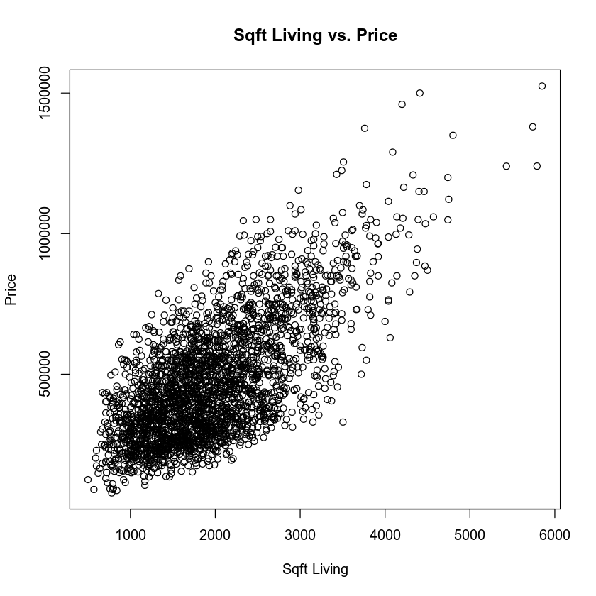

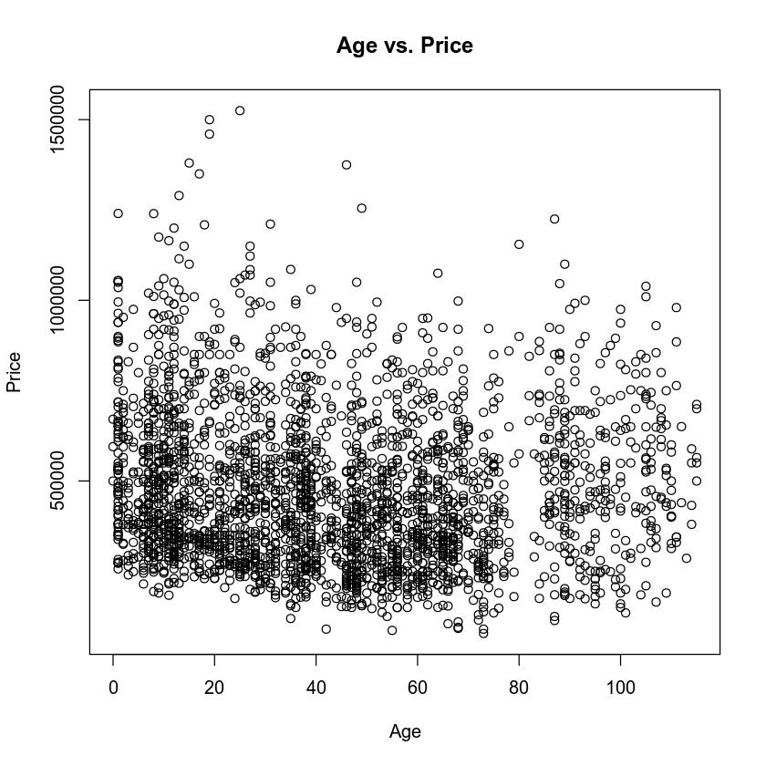

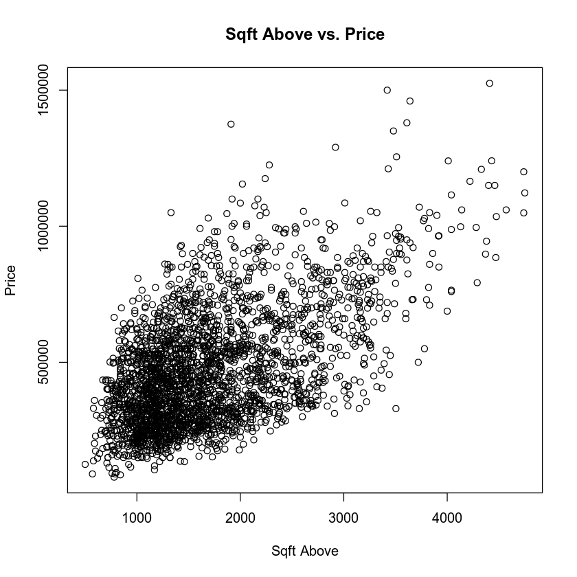

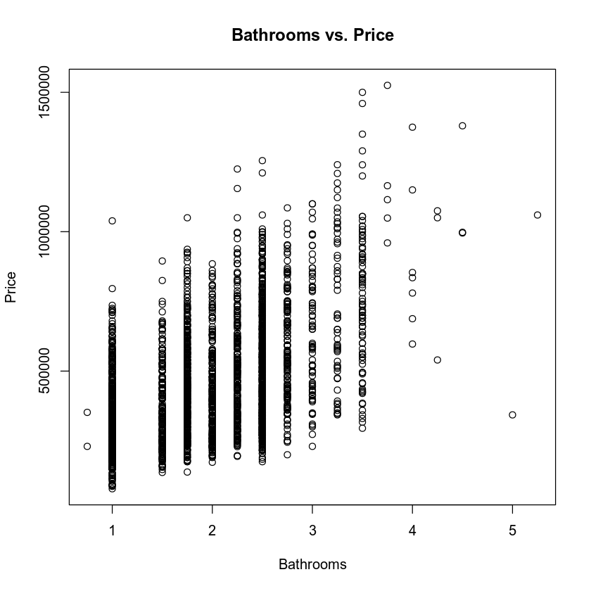

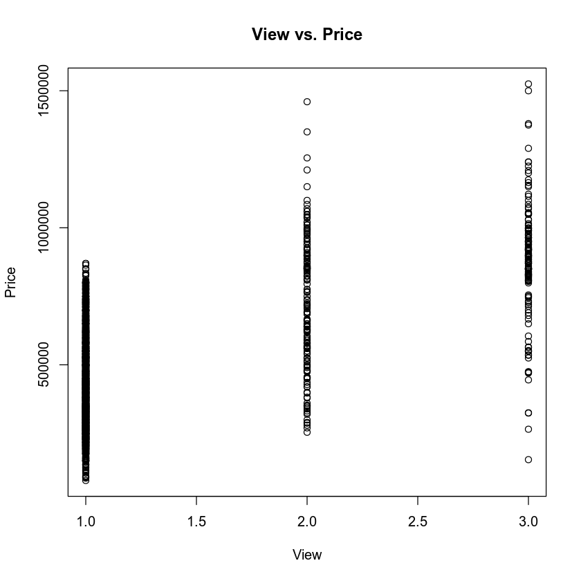

```r
correlation_sqft_living <- cor(housing$sqft_living, housing$price)
correlation_age <- cor(housing$age, housing$price)
correlation_sqft_above <- cor(housing$sqft_above, housing$price)
correlation_bathrooms <- cor(housing$bathrooms, housing$price)
correlation_view <- cor(housing$view, housing$price)

# Create scatterplots for quantitative variables
plot(housing$sqft_living,
     housing$price,
     xlab = "Sqft Living",
     ylab = "Price",
     main = "Sqft Living vs. Price"
    )

plot(housing$age,
     housing$price,
     xlab = "Age",
     ylab = "Price",
     main = "Age vs. Price"
    )

plot(housing$sqft_above,
     housing$price,
     xlab = "Sqft Above",
     ylab = "Price",
     main = "Sqft Above vs. Price"
    )

plot(housing$bathrooms,
     housing$price,
     xlab = "Bathrooms",
     ylab = "Price",
     main = "Bathrooms vs. Price"
    )

plot(housing$view,
     housing$price,
     xlab = "View",
     ylab = "Price",
     main = "View vs. Price"
    )
```

```r
# Overall F-test
cat("Overall F-test: \n")
anova(model1)
```

```
Overall F-test:
```

A anova: 6 × 5

|  | Df <int> | Sum Sq <dbl> | Mean Sq <dbl> | F value <dbl> | Pr(>F) <dbl> |
| --- | --- | --- | --- | --- | --- |
| sqft_living | 1 | 5.737033e+13 | 5.737033e+13 | 3213.98015 | 0.000000e+00 |
| sqft_above | 1 | 2.714749e+11 | 2.714749e+11 | 15.20847 | 9.863080e-05 |
| age | 1 | 3.741654e+12 | 3.741654e+12 | 209.61359 | 8.468380e-46 |
| bathrooms | 1 | 1.103222e+12 | 1.103222e+12 | 61.80430 | 5.445902e-15 |
| view | 2 | 1.026651e+13 | 5.133254e+12 | 287.57332 | 6.868419e-114 |
| Residuals | 2685 | 4.792790e+13 | 1.785024e+10 | NA | NA |

```r
# Fit a first-order regression model with qualitative and quantitative predictor variables
model1 <- lm(price ~ sqft_living + sqft_above + age + bathrooms + view, data = housing)

# Summary of the regression model
summary(model1)

# Obtain residuals and fitted values
residuals1 <- residuals(model1)
fitted1 <- fitted(model1)

# Print the first few rows of residuals and fitted values
cat("1st 6 Model 1 Residual Values: \n")
head(residuals1)
cat("1st 6 Model 1 Fitted Values: \n")
head(fitted1)
```

```
Call:
lm(formula = price ~ sqft_living + sqft_above + age + bathrooms +
    view, data = housing)

Residuals:
    Min      1Q  Median      3Q     Max
-437662 -102015   -5606   93195  521114

Coefficients:
              Estimate Std. Error t value Pr(>|t|)
(Intercept) -1.268e+05  1.374e+04  -9.229  < 2e-16 ***
sqft_living  1.308e+02  8.134e+00  16.076  < 2e-16 ***
sqft_above   1.850e+01  7.472e+00   2.476   0.0134 *
age          1.472e+03  1.201e+02  12.261  < 2e-16 ***
bathrooms    4.449e+04  6.140e+03   7.247 5.55e-13 ***
view         1.327e+05  5.619e+03  23.618  < 2e-16 ***
---
Signif. codes:  0 '***' 0.001 '**' 0.01 '*' 0.05 '.' 0.1 ' ' 1

Residual standard error: 133900 on 2686 degrees of freedom
Multiple R-squared:  0.6007,	Adjusted R-squared:    0.6
F-statistic: 808.2 on 5 and 2686 DF,  p-value: < 2.2e-16
```

```
1st 6 Model 1 Residual Values:
```

**1**

-351499.38763168

**2**

-68140.9003331245

**3**

193920.475394691

**4**

-70046.7840912312

**5**

106978.230731371

**6**

-107292.233117421

```
1st 6 Model 1 Fitted Values:
```

**1**

676499.38763168

**2**

813140.900333124

**3**

377079.524605309

**4**

465046.784091231

**5**

342971.769268629

**6**

350292.233117421

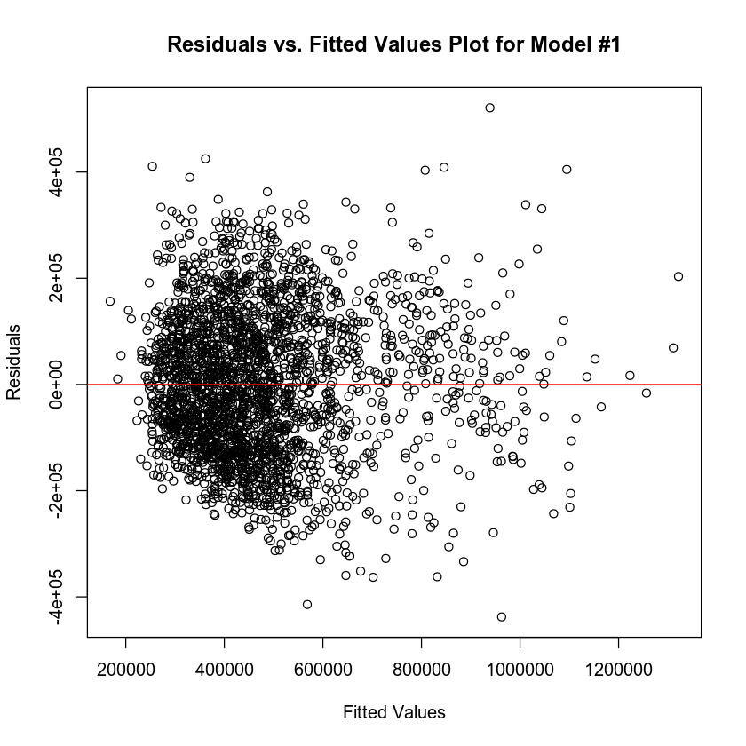

```r
# Create residuals vs. fitted values plot
plot(fitted1, residuals1,
     xlab = "Fitted Values",
     ylab = "Residuals",
     main = "Residuals vs. Fitted Values Plot for Model #1"
)
abline(h = 0, col = "red")  # Add a horizontal line at y = 0
```

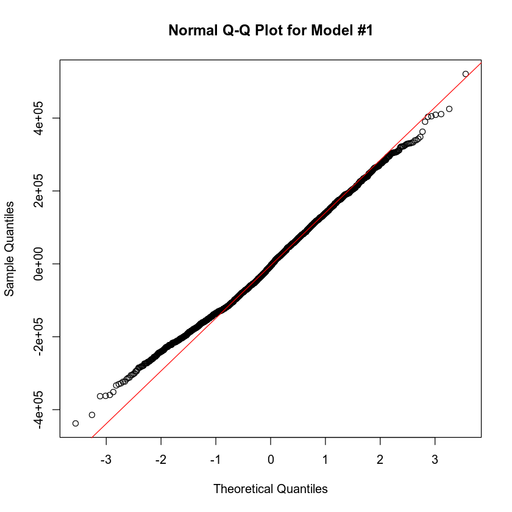

```r
# Create normal Q-Q plot
qqnorm(residuals1,
       xlab = "Theoretical Quantiles",
       ylab = "Sample Quantiles",
       main = "Normal Q-Q Plot for Model #1"
)
qqline(residuals1, col = "red")  # Add a reference line
```

```r
#While the rubric and instructions did not explicitly say that we needed to do a reduced model
#for model 1, I am including it to be sure I meet the rubric requirements.

#Reduced model 1
null_model <- lm(price ~ 1, data = housing)
# Perform an F-test to compare the two models
anova_result <- anova(null_model, model1)

# Print the F-test result
print(anova_result)
```

```
Analysis of Variance Table

Model 1: price ~ 1
Model 2: price ~ sqft_living + sqft_above + age + bathrooms + view
  Res.Df        RSS Df  Sum of Sq      F    Pr(>F)
1   2691 1.2068e+14
2   2686 4.8187e+13  5 7.2494e+13 808.18 < 2.2e-16 ***
---
Signif. codes:  0 '***' 0.001 '**' 0.01 '*' 0.05 '.' 0.1 ' ' 1
```

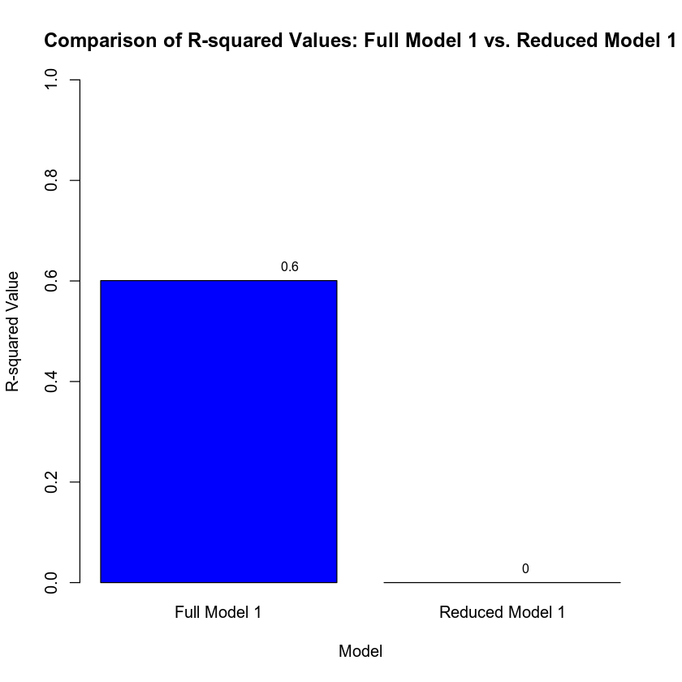

```r
# Fit the full Model 1
model1_full <- lm(price ~ sqft_living + sqft_above + age + bathrooms + view, data = housing)

# Fit the reduced model (null model) for Model 1
model1_reduced <- lm(price ~ 1, data = housing)

# Calculate RSS for both models
rss_model1_full <- sum(model1_full$residuals^2)
rss_model1_reduced <- sum(model1_reduced$residuals^2)

# Calculate R-squared for both models
rsquared_model1_full <- 1 - (rss_model1_full / sum((housing$price - mean(housing$price))^2))
rsquared_model1_reduced <- 1 - (rss_model1_reduced / sum((housing$price - mean(housing$price))^2))

# Create a data frame for plotting
model_names <- c("Full Model 1", "Reduced Model 1")
rsquared_values <- c(rsquared_model1_full, rsquared_model1_reduced)
comparison_data <- data.frame(Model = model_names, R_squared = rsquared_values)

# Create a bar plot
barplot(comparison_data$R_squared,
        names.arg = comparison_data$Model,
        main = "Comparison of R-squared Values: Full Model 1 vs. Reduced Model 1",
        xlab = "Model",
        ylab = "R-squared Value",
        col = c("blue", "red"),
        ylim = c(0, 1)  # Set the y-axis range from 0 to 1
)

# Add text labels above the bars
text(x = 1:2,
     y = comparison_data$R_squared,
     labels = round(comparison_data$R_squared, 2),
     pos = 3,
     cex = 0.8)
```

```r
# Predicting the price for the first home
new_home1 <- data.frame(sqft_living = 2150,
                        sqft_above = 1050,
                        age = 15,
                        bathrooms = 3,
                        view = 0)   #Road view

# Predict the price
predicted_price1 <- predict(model1_full,
                            newdata = new_home1,
                            interval = "prediction",
                            level = 0.90)

# Display the prediction and prediction interval
cat("Predicted Price for Home 1: $",
    predicted_price1[1],
    "\n")
cat("90% Prediction Interval for Home 1: [$",
    predicted_price1[2],
    " - $",
    predicted_price1[3],
    "]\n")

# Predicting the price for the second home
new_home2 <- data.frame(sqft_living = 4250,
                        sqft_above = 2100,
                        age = 5,
                        bathrooms = 5,
                        view = 1)  #waterfront view
# Predict the price
predicted_price2 <- predict(model1_full,
                            newdata = new_home2,
                            interval = "prediction",
                            level = 0.90)

# Display the prediction and prediction interval
cat("Predicted Price for Home 2: $",
    predicted_price2[1],
    "\n")
cat("90% Prediction Interval for Home 2: [$",
    predicted_price2[2],
    " - $",
    predicted_price2[3],
    "]\n")
```

```
Predicted Price for Home 1: $ 329349.3
90% Prediction Interval for Home 1: [$ 108264.1  - $ 550434.5 ]
Predicted Price for Home 2: $ 830347.9
90% Prediction Interval for Home 2: [$ 608274.6  - $ 1052421 ]
```

```r
#Full Model 1 is the best fit between the two compared above, due it accounting for approximately 60%
# of the variability in the housing prices can be accounted for by the combination of predictor
#variables (sqft_living, sqft_above, age, bathrooms, and view) included in this model.
#While Reduced model 1 only includes an intercept term (no predictor variables),
#so it cannot explain any of the variability in housing prices based on the given data.
```

# Model #2 - Complete Second Order Regression Model with Quantitative Variables

You have been asked to create a complete second order regression model for *price* as the response variable, and *school_rating* and *crime* as predictor variables. Before writing any code, review Section 4 of the Summary Report template to see the questions you will be answering about your complete second order multiple regression model.

Run your scripts to get the outputs of your regression analysis. Then use the outputs to answer the questions in your summary report.

**Note: Use the + (plus) button to add new code blocks, if needed.**

```r
# Fit a complete second-order regression model with school_rating and crime as predictor variables
model2 <- lm(price ~ school_rating + crime + I(school_rating^2) + I(crime^2) + school_rating:crime, data = housing)

# Summary of the regression model
summary(model2)
```

```
Call:
lm(formula = price ~ school_rating + crime + I(school_rating^2) +
    I(crime^2) + school_rating:crime, data = housing)

Residuals:
    Min      1Q  Median      3Q     Max
-340729  -61055   -6288   56875  427915

Coefficients:
                      Estimate Std. Error t value Pr(>|t|)
(Intercept)          7.339e+05  1.032e+05   7.113 1.45e-12 ***
school_rating       -7.375e+04  2.083e+04  -3.541 0.000406 ***
crime               -3.155e+03  5.235e+02  -6.027 1.90e-09 ***
I(school_rating^2)   1.165e+04  1.109e+03  10.497  < 2e-16 ***
I(crime^2)           6.377e+00  7.265e-01   8.777  < 2e-16 ***
school_rating:crime -5.227e+01  4.853e+01  -1.077 0.281513
---
Signif. codes:  0 '***' 0.001 '**' 0.01 '*' 0.05 '.' 0.1 ' ' 1

Residual standard error: 92690 on 2686 degrees of freedom
Multiple R-squared:  0.8088,	Adjusted R-squared:  0.8084
F-statistic:  2272 on 5 and 2686 DF,  p-value: < 2.2e-16
```

```r
# Obtain residuals and fitted values
residuals2 <- residuals(model2)
fitted2 <- fitted(model2)

# Print the first few rows of residuals and fitted values
cat("1st 6 Model 2 Residual Values: \n")
head(residuals2)
cat("1st 6 Model 2 Fitted Values: \n")
head(fitted2)

# Create scatterplots and calculate correlation coefficients
correlation_crime <- cor(housing$crime, housing$price)
correlation_sr <- cor(housing$school_rating, housing$price)



# Print correlation coefficients
cat("Crime Correlation: ")
cat(correlation_crime)
cat("\nSchool Rating Correlation: ")
cat(correlation_sr)
```

```
1st 6 Model 2 Residual Values:
```

**1**

8204.12961932669

**2**

14009.7509066727

**3**

733.831563462927

**4**

-29499.9634746599

**5**

-170192.715084432

**6**

-34655.2039171532

```
1st 6 Model 2 Fitted Values:
```

**1**

316795.870380673

**2**

730990.249093327

**3**

570266.168436537

**4**

424499.96347466

**5**

620142.715084432

**6**

277655.203917153

```
Crime Correlation: -0.7683115
School Rating Correlation: 0.7859513
```

```r
#Prediction
school_rating_1 <- 9.80
crime_1 <- 81.02

# Calculate the predicted price
predicted_price_1 <- 733910.73 - 73748.17 * school_rating_1 - 3154.77 * crime_1 +
                      11646.80 * (school_rating_1^2) + 6.38 * (crime_1^2) -
                      52.27 * school_rating_1 * crime_1

# Print the predicted price
cat("Predicted Price 1: ", predicted_price_1)


# Calculate 90% prediction interval
pred_interval_1 <- predict(model2, newdata = data.frame(school_rating = school_rating_1, crime = crime_1), interval = "prediction", level = 0.90)

# Calculate 90% confidence interval
conf_interval_1 <- predict(model2, newdata = data.frame(school_rating = school_rating_1, crime = crime_1), interval = "confidence", level = 0.90)

# Print the prediction and confidence intervals
pred_interval_1
cat("\nPrediction Interval 1: ", pred_interval_1)
conf_interval_1
cat("\nConfidence Interval 1: ", conf_interval_1)
```

```
Predicted Price 1:  874515.6
```

A matrix: 1 × 3 of type dbl

| fit | lwr | upr |
| --- | --- | --- |
| 874497 | 721606.2 | 1027388 |

```
Prediction Interval 1:  874497 721606.2 1027388
```

A matrix: 1 × 3 of type dbl

| fit | lwr | upr |
| --- | --- | --- |
| 874497 | 863681.4 | 885312.7 |

```
Confidence Interval 1:  874497 863681.4 885312.7
```

```r
# Define the values for the second scenario
school_rating_2 <- 4.28
crime_2 <- 215.50

# Calculate the predicted price for the second scenario
predicted_price_2 <- 733910.73 - 73748.17 * school_rating_2 - 3154.77 * crime_2 +
                      11646.80 * (school_rating_2^2) + 6.38 * (crime_2^2) -
                      52.27 * school_rating_2 * crime_2

# Print the predicted price for the second scenario
cat("Predicted Price 2: ", predicted_price_2)

# Calculate the 90% prediction interval for the second scenario
pred_interval_2 <- predict(model2, newdata = data.frame(school_rating = school_rating_2, crime = crime_2), interval = "prediction", level = 0.90)

# Calculate the 90% confidence interval for the second scenario
conf_interval_2 <- predict(model2, newdata = data.frame(school_rating = school_rating_2, crime = crime_2), interval = "confidence", level = 0.90)

# Print the prediction interval for the second scenario
pred_interval_2
cat("\nPrediction Interval 2: ", pred_interval_2)
conf_interval_2
# Print the confidence interval for the second scenario
cat("\nConfidence Interval 2: ",conf_interval_2)
```

```
Predicted Price 2:  199844.5
```

A matrix: 1 × 3 of type dbl

| fit | lwr | upr |
| --- | --- | --- |
| 199706.7 | 46991.65 | 352421.7 |

```
Prediction Interval 2:  199706.7 46991.65 352421.7
```

A matrix: 1 × 3 of type dbl

| fit | lwr | upr |
| --- | --- | --- |
| 199706.7 | 191753.5 | 207659.9 |

```
Confidence Interval 2:  199706.7 191753.5 207659.9
```

```r
# Create the complete second-order model
model_second_order <- lm(price ~ school_rating + crime + I(school_rating^2) + I(crime^2) + school_rating:crime, data = housing)

# Obtain the summary of the model
summary(model_second_order)
```

```
Call:
lm(formula = price ~ school_rating + crime + I(school_rating^2) +
    I(crime^2) + school_rating:crime, data = housing)

Residuals:
    Min      1Q  Median      3Q     Max
-340729  -61055   -6288   56875  427915

Coefficients:
                      Estimate Std. Error t value Pr(>|t|)
(Intercept)          7.339e+05  1.032e+05   7.113 1.45e-12 ***
school_rating       -7.375e+04  2.083e+04  -3.541 0.000406 ***
crime               -3.155e+03  5.235e+02  -6.027 1.90e-09 ***
I(school_rating^2)   1.165e+04  1.109e+03  10.497  < 2e-16 ***
I(crime^2)           6.377e+00  7.265e-01   8.777  < 2e-16 ***
school_rating:crime -5.227e+01  4.853e+01  -1.077 0.281513
---
Signif. codes:  0 '***' 0.001 '**' 0.01 '*' 0.05 '.' 0.1 ' ' 1

Residual standard error: 92690 on 2686 degrees of freedom
Multiple R-squared:  0.8088,	Adjusted R-squared:  0.8084
F-statistic:  2272 on 5 and 2686 DF,  p-value: < 2.2e-16
```

```r
#Now fit the second order model
coefs <- coef(model_second_order)

print(coefs)

#define coefficients
b0 <- coefs[1]
b1 <- coefs[2]
b2 <- coefs[3]
ba <- coefs[4]
bb <- coefs[5]
bc <- coefs[6]

#Write prediction model equation
pred_equation <- paste(
    "Price = ",
    b0,
    " + ",
    b1,
    " * school_rating + ",
    b2,
    " * crime + ",
    ba,
    " * (school_rating^2) + ",
    bb,
    " * (crime^2) + ",
    bc,
    " * school_rating * crime + epsilon"
)

#Print the prediction equation
cat("\nPrediction Model Equation: \n", pred_equation, "\n")
```

```
        (Intercept)       school_rating               crime  I(school_rating^2)
       733910.73431        -73748.17286         -3154.76648         11646.80277
         I(crime^2) school_rating:crime
            6.37700           -52.26921

Prediction Model Equation:
 Price =  733910.734314471  +  -73748.1728603468  * school_rating +  -3154.76647579406  * crime +  11646.8027698968  * (school_rating^2) +  6.37700048040213  * (crime^2) +  -52.2692092196072  * school_rating * crime + epsilon
```

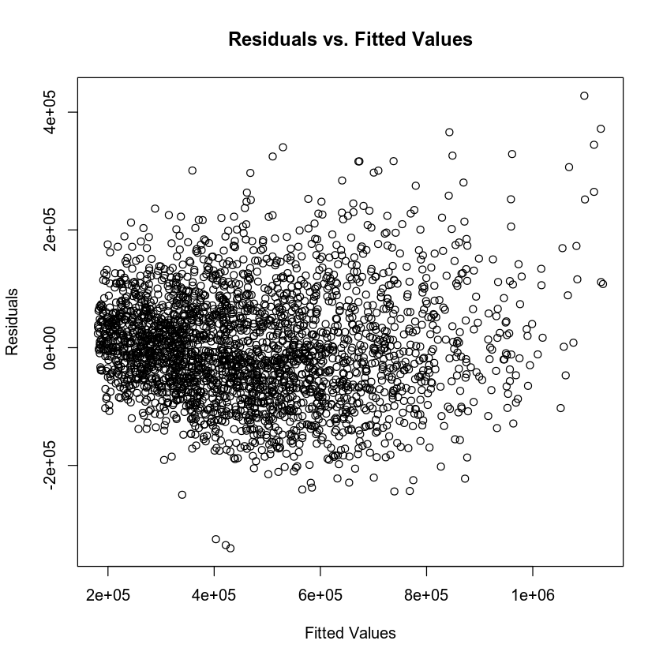

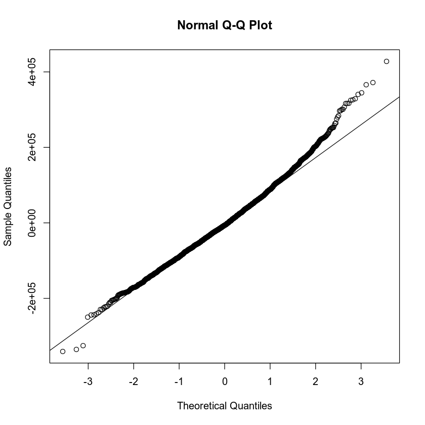

```r
# Obtain residuals and fitted values
residuals_second_order <- residuals(model_second_order)
fitted_values_second_order <- fitted(model_second_order)

# Create a scatterplot of residuals vs. fitted values
plot(fitted_values_second_order, residuals_second_order, xlab = "Fitted Values", ylab = "Residuals",
     main = "Residuals vs. Fitted Values")

# Create a Normal Q-Q plot
qqnorm(residuals_second_order, main = "Normal Q-Q Plot")
qqline(residuals_second_order)
```

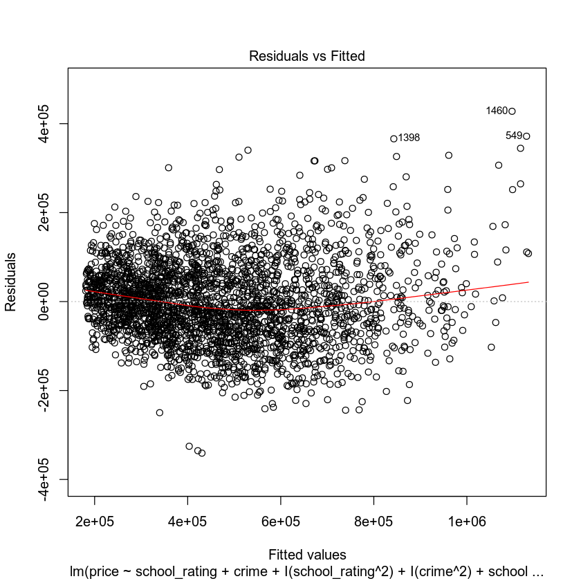

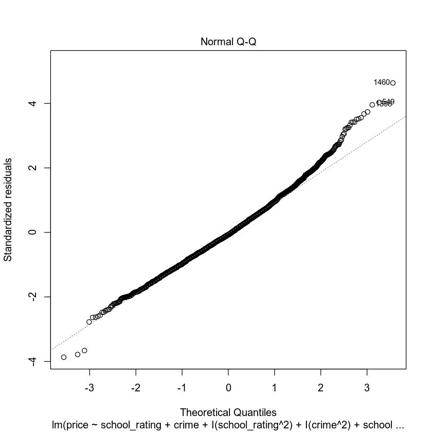

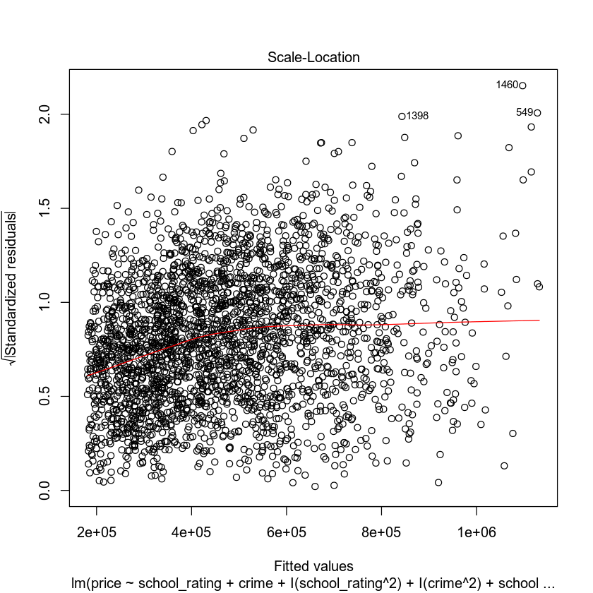

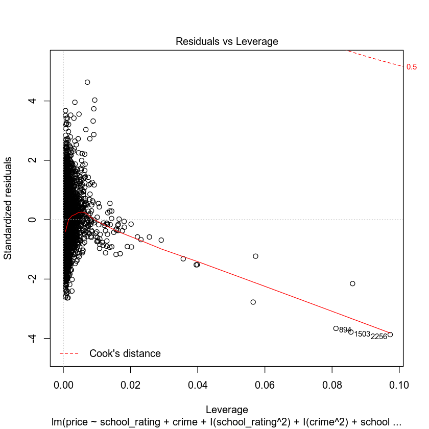

```r
#Create diagnostic plots to assess model assumptions

#residuals vs fitted  (checking for linearity and homoscedasticity)
plot(model_second_order, which = 1)

#Normal Q-Q plot (check normality of residuals)
plot(model_second_order, which = 2)

#scale-location plot (check for homoscedasticity)
plot(model_second_order, which = 3)

#residuals vs leverage plot (check for influential points)
plot(model_second_order, which = 5)
```

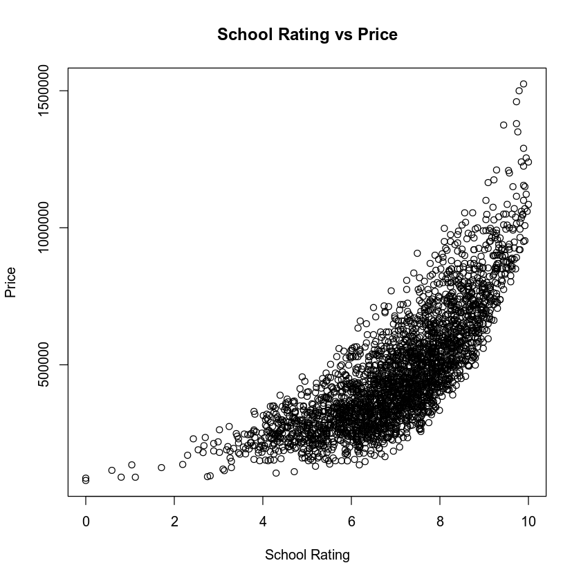

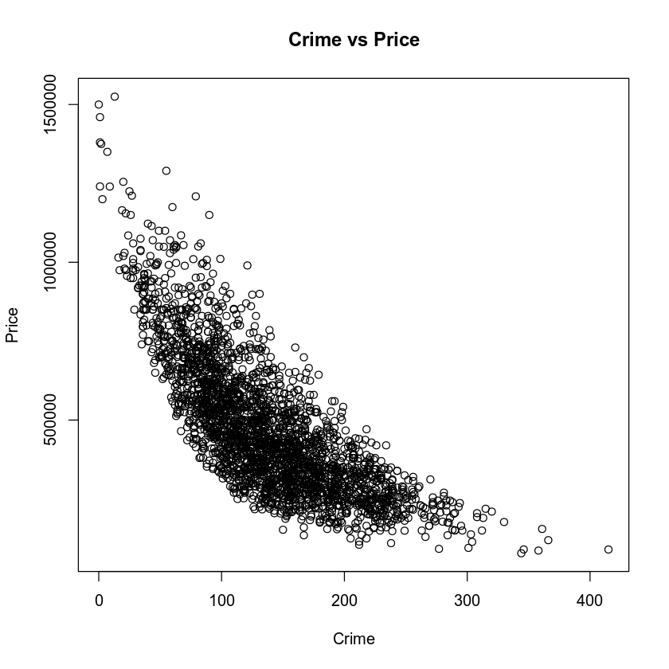

```r
#scatterplot of school_rating vs price
plot(housing$school_rating,
     housing$price,
     xlab = "School Rating",
     ylab = "Price",
     main = "School Rating vs Price")

#Create scatterplot for crime vs price
plot(housing$crime,
     housing$price,
     xlab = "Crime",
     ylab = "Price",
     main = "Crime vs Price")
```

```r
#Overall F-test
null_model2 <- lm(price~ 1, data = housing)
mod2Ftest <- anova(null_model2, model2)

#Print results
print(mod2Ftest)
```

```
Analysis of Variance Table

Model 1: price ~ 1
Model 2: price ~ school_rating + crime + I(school_rating^2) + I(crime^2) +
    school_rating:crime
  Res.Df        RSS Df  Sum of Sq      F    Pr(>F)
1   2691 1.2068e+14
2   2686 2.3075e+13  5 9.7606e+13 2272.4 < 2.2e-16 ***
---
Signif. codes:  0 '***' 0.001 '**' 0.01 '*' 0.05 '.' 0.1 ' ' 1
```

```r
#create reduced model for model 2
r_model2 <- lm(price~ school_rating + crime, data = housing)

#Compare model 2 to reduced model 2
anova(model_second_order, r_model2)
```

A anova: 2 × 6

| Res.Df <dbl> | RSS <dbl> | Df <dbl> | Sum of Sq <dbl> | F <dbl> | Pr(>F) <dbl> |
| --- | --- | --- | --- | --- | --- |
| 2686 | 2.307469e+13 | NA | NA | NA | NA |
| 2689 | 3.320113e+13 | -3 | -1.012644e+13 | 392.9212 | 1.388009e-211 |

# Nested Models F-Test

You have been asked to create a reduced model and compare it with the complete second order model (Model #2 above). Before writing any code, review Section 5 of the Summary Report template to see the questions you will need to answer.

Run your scripts to get the outputs of your regression analysis. Then use the outputs to answer the questions in your summary report.

**Note: Use the + (plus) button to add new code blocks, if needed.**

```r
#perform the F-test to compare full second order model2 vs redudeced model2
a_result <- anova(r_model2, model_second_order)

#Print the a_result
print(a_result)
```

```
Analysis of Variance Table

Model 1: price ~ school_rating + crime
Model 2: price ~ school_rating + crime + I(school_rating^2) + I(crime^2) +
    school_rating:crime
  Res.Df        RSS Df  Sum of Sq      F    Pr(>F)
1   2689 3.3201e+13
2   2686 2.3075e+13  3 1.0126e+13 392.92 < 2.2e-16 ***
---
Signif. codes:  0 '***' 0.001 '**' 0.01 '*' 0.05 '.' 0.1 ' ' 1
```

```r
#First order full model 2
full_model <- lm(price ~ school_rating + crime + school_rating:crime, data = housing)
#reduced model 2
reduced_model <- lm(price ~ school_rating + crime, data = housing)
#Compare the two models
anova_result <- anova(reduced_model, full_model)

#print the results
print(anova_result)
```

```
Analysis of Variance Table

Model 1: price ~ school_rating + crime
Model 2: price ~ school_rating + crime + school_rating:crime
  Res.Df        RSS Df  Sum of Sq      F    Pr(>F)
1   2689 3.3201e+13
2   2688 2.4195e+13  1 9.0061e+12 1000.6 < 2.2e-16 ***
---
Signif. codes:  0 '***' 0.001 '**' 0.01 '*' 0.05 '.' 0.1 ' ' 1
```

```r
# Perform ANOVA to compare models
anova_result <- anova(model1, model_second_order)

# Print the ANOVA table
print(anova_result)

f_test <- anova(model1, model_second_order)

#Extract p-value from f-test
p_val <- f_test$`Pr(>F)`[2]

#print p-value
print(p_val)
```

```
Analysis of Variance Table

Model 1: price ~ sqft_living + sqft_above + age + bathrooms + view
Model 2: price ~ school_rating + crime + I(school_rating^2) + I(crime^2) +
    school_rating:crime
  Res.Df        RSS Df  Sum of Sq F Pr(>F)
1   2686 4.8187e+13
2   2686 2.3075e+13  0 2.5112e+13
[1] NA
```

```r
# Fit a first-order regression model with interaction
model_first_order <- lm(price ~ school_rating * crime, data = housing)

# Summary of the regression model
summary(model_first_order)

# Get the coefficients
coefs <- coef(model_first_order)

# Define coefficients
b0 <- coefs[1]
b1 <- coefs[2]
b2 <- coefs[3]
b3 <- coefs[4]

# Write prediction model equation
pred_equation <- paste(
  "Price = ",
  b0,
  " + ",
  b1,
  " * school_rating + ",
  b2,
  " * crime + ",
  b3,
  " * (school_rating * crime) + epsilon"
)

# Print the prediction equation
cat("\nPrediction Model Equation (First Order with Interaction): \n", pred_equation, "\n")
```

```
Call:
lm(formula = price ~ school_rating * crime, data = housing)

Residuals:
    Min      1Q  Median      3Q     Max
-336984  -63754   -4397   58894  440377

Coefficients:
                      Estimate Std. Error t value Pr(>|t|)
(Intercept)         -410233.37   25261.25  -16.24   <2e-16 ***
school_rating        155559.97    3133.06   49.65   <2e-16 ***
crime                  2230.07     129.70   17.20   <2e-16 ***
school_rating:crime    -564.85      17.86  -31.63   <2e-16 ***
---
Signif. codes:  0 '***' 0.001 '**' 0.01 '*' 0.05 '.' 0.1 ' ' 1

Residual standard error: 94870 on 2688 degrees of freedom
Multiple R-squared:  0.7995,	Adjusted R-squared:  0.7993
F-statistic:  3573 on 3 and 2688 DF,  p-value: < 2.2e-16
```

```
Prediction Model Equation (First Order with Interaction):
 Price =  -410233.374408012  +  155559.967789628  * school_rating +  2230.07429402306  * crime +  -564.845854956222  * (school_rating * crime) + epsilon
```

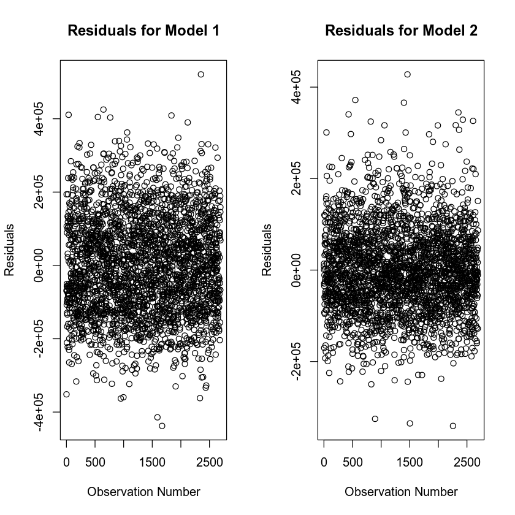

```r
# Create a residuals plot
par(mfrow=c(1,2)) # Set up a 1x2 grid for two plots side by side
plot(model1$residuals,
     main="Residuals for Model 1",
     ylab="Residuals",
     xlab="Observation Number")
plot(model_second_order$residuals,
     main="Residuals for Model 2",
     ylab="Residuals",
     xlab="Observation Number")
```

## End of Project One Jupyter Notebook

The HTML output can be downloaded by clicking **File**, then **Download as**, then **HTML**. Be sure to answer all of the questions in the Summary Report template for Project One, and to include your completed Jupyter Notebook scripts as part of your submission.